# STAT 4280 Final Project

Andrew Benecchi

12/7/2020

## Data Set Title

```
## Feather River monthly flow rate in cubic meters/s at Oroville, California, Oct.1902 – Sep. 1961
```

## About the Feather River

The Feather River is the principal tributary of the Sacramento River, which discharges into the Suisun Bay, a tidal estuary of the San Francisco Bay Area. The measurements in the time series, according to the Time Series Data Library, were conducted between 10/1902 and 09/1977, but the data actually only appears to be complete through 09/1961, the same year which construction on the Oroville Dam began in earnest; the partially-completed Oroville Dam mitigated the local impact of the Pacific Northwest-wide Christmas floods of 1964, which caused a peak flow of 7100 $\frac{m^{3}}{s}$. The Oroville Dam is the tallest dam in the US, at 235 m in height, and uses 480 $\frac{m^{3}}{s}$ of its flow limit of 4200 $\frac{m^{3}}{s}$ to generate power.

## Time series of data

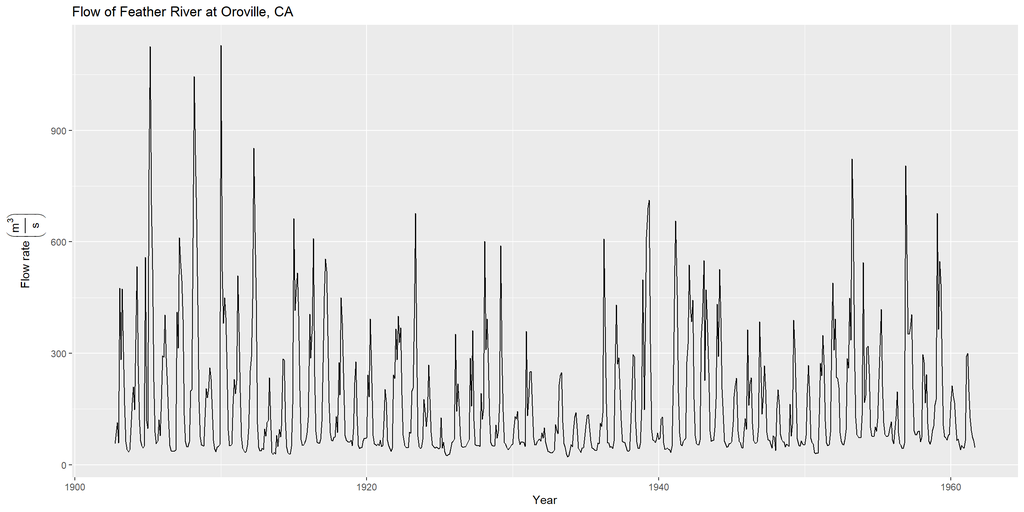

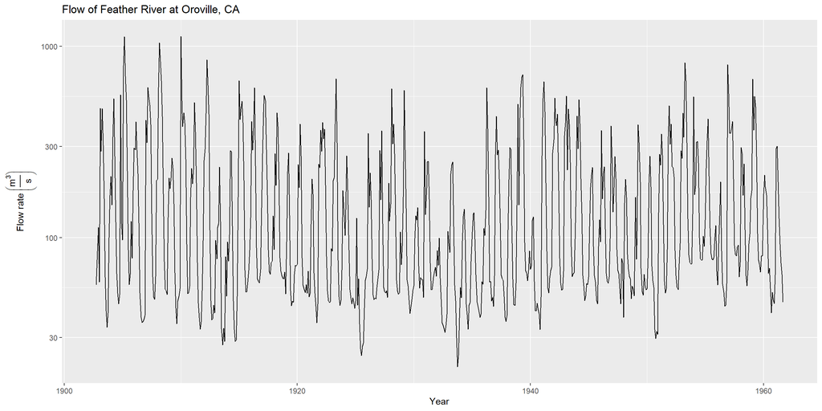

The data need a variable transformation in order to stabilize the variance; a Box-Cox analysis should optimize the $\lambda$ necessary to stabilize the variance as much as possible.

## Box-Cox Transformation

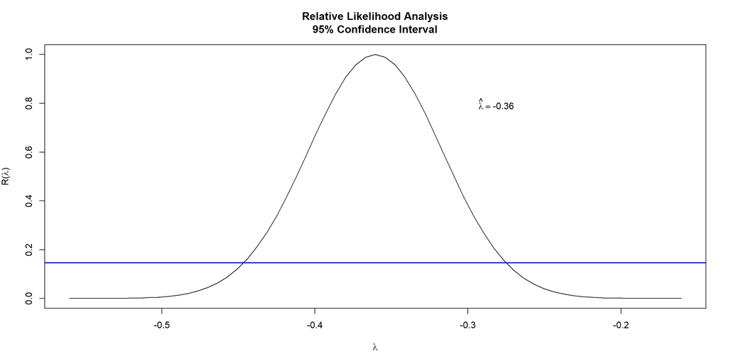

## Analysis Techniques

The data is split into training (n=672) and testing (n=36) datasets for most graphical comparison of prediction errors, though different testing-training splits are necessary to evaluate the consistency of the quality of the models. SARIMA models are chosen using analysis of the periodogram and the sample’s year-over-year $(1-B^{12})$, and differenced year-over-year $(1-B)(1-B^{12})$ ACF and PACF graphs. Quality of the SARIMA models is evaluated by comparing AICs, BICs, RMSE, MAPE, and MRPE, the latter of which is calculated as follows:

$$\frac{1}{t_{max}} \sum_{1}^{t_{max}}\frac{|Prediction_{i} - Actual_{i}|}{Actual_{i}}$$

Once a final candidate SARIMA model is found, then the best models through LOWESS decomposition and exponential smoothing are found. The LOWESS models are compared by RMSE across different variable transformations (with RMSE being representative of the gap between actual and the model’s detransformed seasonal+trend parts), and the predictions are compared across the four types (ETS, ARIMA, naive (i.e. no evolution in predicted points), and random walk with drift), resulting in 12 possible models that may provide the best MAPE for a given testing length. The exponential smoothing methods are compared by RMSE and MAPE across variable transformations and by seasonality calculation method (i.e. additive or multiplicative). The best models found through triple exponential smoothing and decomposition using the classical method and locally-weighted least-squares are compared to the SARIMA model.

## Analyzing the transformed data

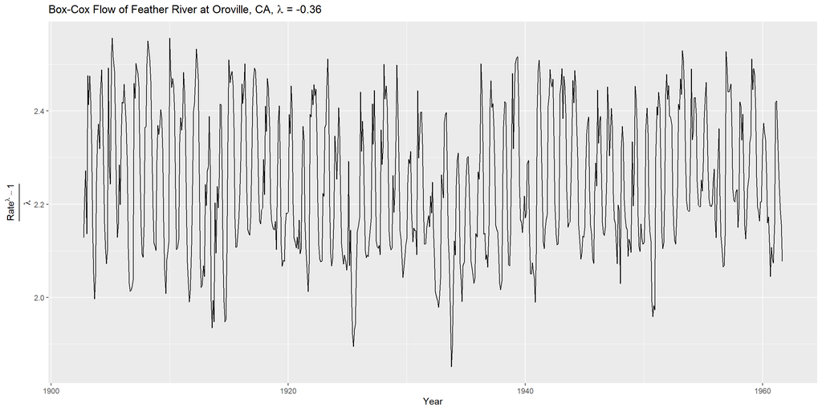

The data appear to have a periodic nature, so analyzing the ACF, PACF, and periodogram are necessary to develop a candidate model.

## ACF and PACF of transformed data

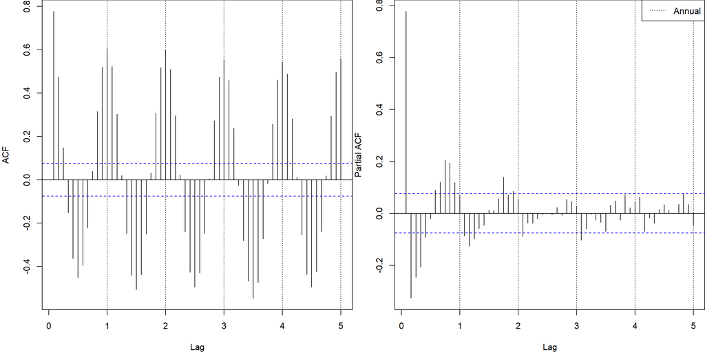

## Analysis of ACF, PACF

The ACF has a persistent sinusoidal pattern, with peaks at lags with annual recurrence, troughs lagged six months behind, similar to a cosine wave with weak decay. The PACF has a dampened sinusoidal pattern, similar to $-e^{-kx}sin{\frac{\pi x}{6}}$ but because $\phi_{11}=\rho(X_{t},X_{t-1})$ the first partial autocorrelation is positive.

## Periodogram of Data

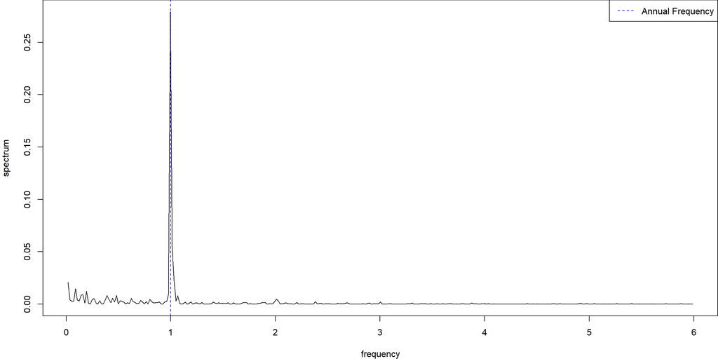

The periodogram has a strong spike at annual recurrence, so investigating the annual differences is necessary.

## Year-over-year changes

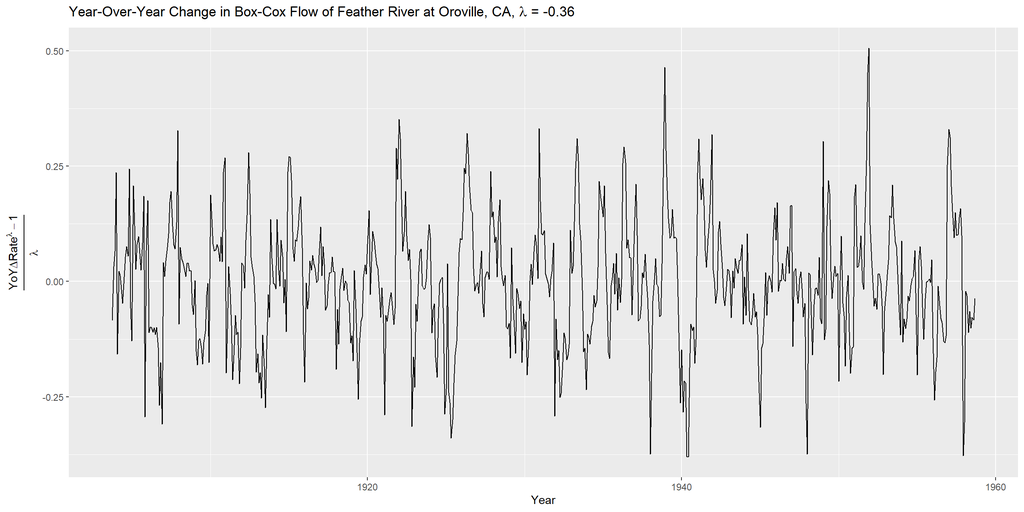

## ACF, PACF of Annually-Differenced Data

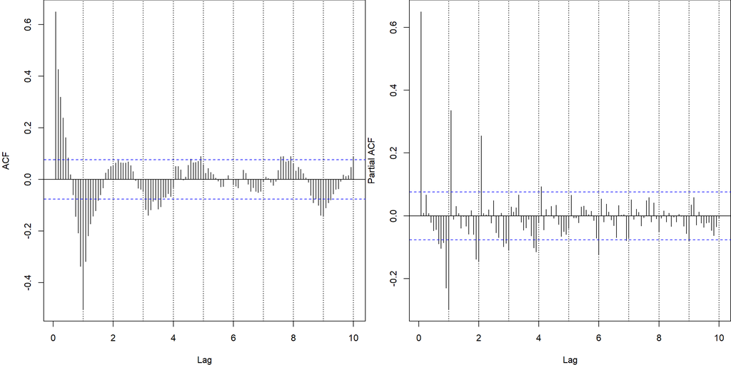

## Analysis of year-over-year change

The ACF exhibits a dampened oscillation that crosses $\rho=0$ every 12 lags around $\rho=6+12k$, with a strong trough at $l=12$. There may be an integrated term in the non-seasonal part, the seasonal part, both, or neither. If there is not seasonal integration, then the seasonal part may be an $ARMA$ form with a large seasonal autoregressive term. The PACF has significant $12k$, $12k+1$ lags of opposite signs that get dampened as $k$ increases; the $\phi$ at $l=12k, 12k+1$ decay slowly without sign change.The seasonal part includes a seasonal moving average term, and if there is a non-seasonal autoregressive term, then that explains the opposing signs of the $\phi$ at $l=12k, 12k+1$.

## Inspecting the monthly change in year-over-year change

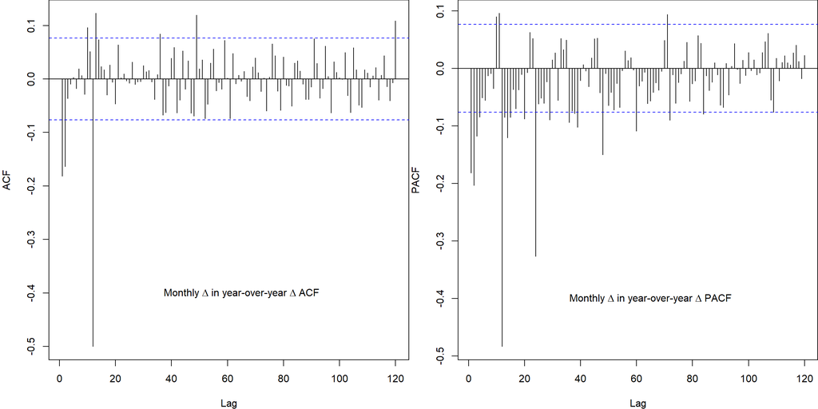

## Analysis of monthly change in YoY change

There is a strong negative spike at $l=12$ in ACF that cuts off, with smaller negative significant lags for $l=1,2$. The PACF has negative spikes without changing signs for $l=12k$, tapering off. There is a strong case to conjecture that the model has a seasonal moving average, as that explains the taper in the lag spikes of the PACF, while a non-seasonal autoregressive term would explain the significant ACF lags at $l=1,2$

The parameter combinations explored are:

$$SARIMA(0 \leq p \leq 1, 0 \leq d \leq 1, 0\leq q \leq 2)\times(0 \leq P \leq 1,0 \leq D \leq 1, Q=1)_{s=12}$$

## Candidate models:

1. Seasonally-Integrated SARIMA ($AR(1) \times SIMA(1,1)_{12}$)
2. Seasonally-Integrated SARIMA ($ARMA(1,2) \times SIMA(1,1)_{12}$)
3. Integrated and Seasonally-Integrated SARIMA ($ARIMA(1,1,1) \times SIMA(1,1)_{12}$)
4. Seasonal ARMA ($AR(1) \times SARMA(1,1)_{12}$)
5. ARIMA with seasonal part ($ARIMA(1,1,1)\times SARMA(1,1)_{12}$)

## Why each?

Each has best AIC in its subtype

1. Best seasonally-integrated AR
2. Best seasonally-integrated ARMA
3. Best integrated seasonally-integrated ARMA
4. Best non-integrated model
5. Best integrated model with seasonal part

## Model Coefficients

```
##
## Call:
## arima(x = ., order = c(1, 0, 0), seasonal = list(order = c(0, 1, 1), period = 12))
##
## Coefficients:
##         ar1     sma1
##       0.674  -0.9532
## s.e.  0.029   0.0256
##
## sigma^2 estimated as 0.005573:  log likelihood = 761.53,  aic = -1519.06
```

```
##
## Call:
## arima(x = ., order = c(1, 0, 2), seasonal = list(order = c(0, 1, 1), period = 12))
##
## Coefficients:
##          ar1      ma1      ma2     sma1
##       0.8083  -0.1733  -0.1204  -0.9507
## s.e.  0.0481   0.0650   0.0544   0.0236
##
## sigma^2 estimated as 0.005528:  log likelihood = 764.55,  aic = -1521.11
```

```
##
## Call:
## arima(x = ., order = c(1, 1, 1), seasonal = list(order = c(0, 1, 1), period = 12))
##
## Coefficients:
##          ar1      ma1     sma1
##       0.6419  -0.9797  -0.9631
## s.e.  0.0334   0.0115   0.0241
##
## sigma^2 estimated as 0.005549:  log likelihood = 758.45,  aic = -1510.89
```

```
##
## Call:
## arima(x = ., order = c(1, 0, 0), seasonal = list(order = c(1, 0, 1), period = 12),
##     include.mean = T)
##
## Coefficients:
##          ar1    sar1     sma1  intercept
##       0.6795  0.9986  -0.9541     2.2496
## s.e.  0.0286  0.0017   0.0266     0.0582
##
## sigma^2 estimated as 0.005565:  log likelihood = 777.39,  aic = -1546.78
```

```
##
## Call:
## arima(x = ., order = c(1, 1, 1), seasonal = list(order = c(1, 0, 1), period = 12))
##
## Coefficients:
##          ar1      ma1    sar1     sma1
##       0.6574  -0.9862  0.9990  -0.9597
## s.e.  0.0318   0.0083  0.0013   0.0244
##
## sigma^2 estimated as 0.00555:  log likelihood = 775.7,  aic = -1543.4
```

The 4th candidate model provides the strongest AIC, but other analysis methods are necessary for more confidence in the model selection process.

## Comparing year-over-year ACFs

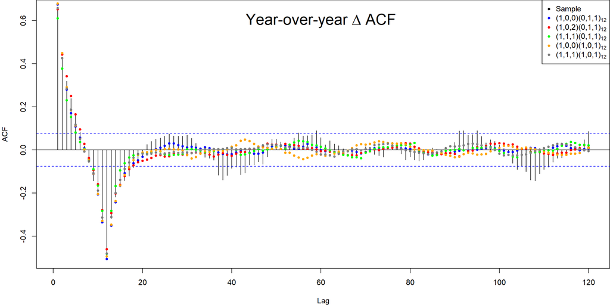

## Comparing year-over-year PACFs

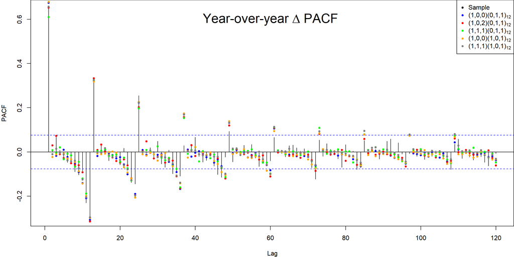

## Comparing differenced year-over-year change ACFs

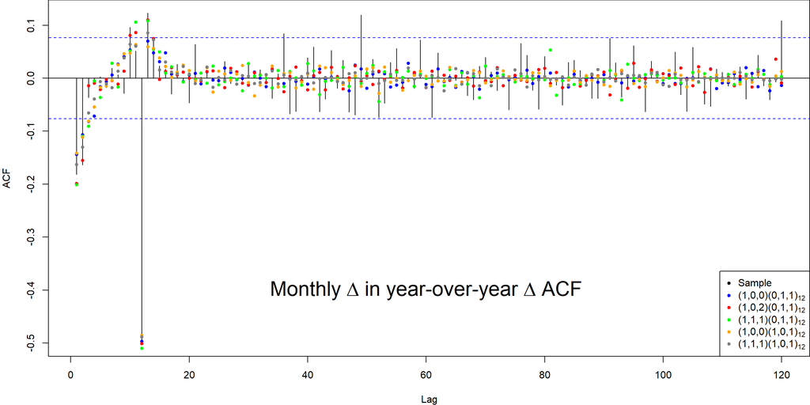

## Comparing differenced year-over-year change PACFs

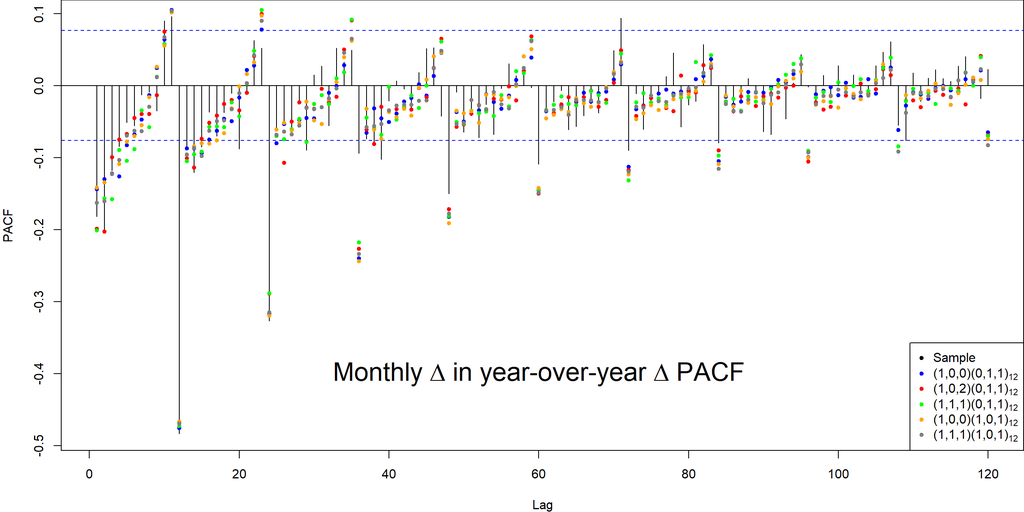

The MA term decay is captured in PACFs for both year-over-year $\Delta$ and monthly $\Delta$ in year-over-year $\Delta$, but the variability in $\rho$ and $\phi$ at later lags worthy of investigation mentioned previously that cannot be captured by any SARIMA model. In order to be more robust in the model-selection process, different training-testing splits should be tested to understand how each model’s quality evolves over time. Similar methods should be applied to the other time series’ model selection methods.

## Best Model Selector for SARIMA

```
##    user  system elapsed
##    0.05    0.10    7.35
```

```
##    training.years which.min.AIC which.min.BIC which.min.RMSE which.min.MAPE
## 1              31             4             4              5              1
## 2              32             4             4              5              1
## 3              33             4             4              5              2
## 4              34             4             4              5              2
## 5              35             4             4              5              2
## 6              36             4             4              5              2
## 7              37             4             4              4              3
## 8              38             4             4              4              1
## 9              39             4             4              4              2
## 10             40             4             4              4              3
## 11             41             4             4              4              2
## 12             42             4             4              4              1
## 13             43             4             4              4              1
## 14             44             4             4              4              3
```

[output cut: 43 more lines]

## Plotting RMSE, MAPE, MRPE

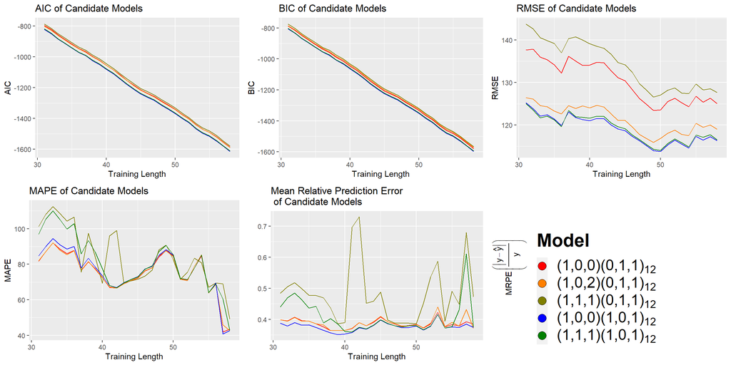

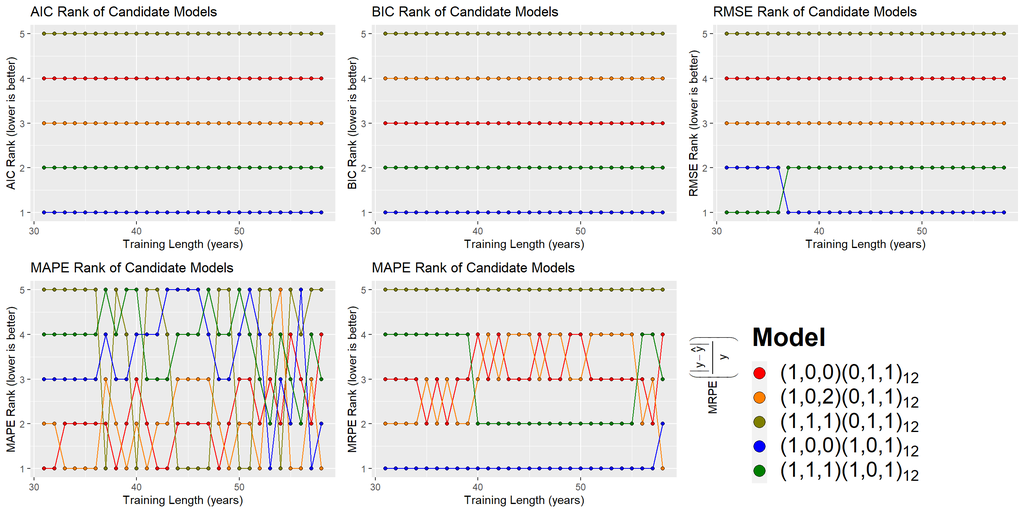

```
##  cm1AICX  cm2AICX  cm3AICX  cm4AICX  cm5AICX  cm1BICX  cm2BICX  cm3BICX
## 4.000000 3.000000 5.000000 1.000000 2.000000 3.000000 4.000000 5.000000
##  cm4BICX  cm5BICX  cm1RMSE  cm2RMSE  cm3RMSE  cm4RMSE  cm5RMSE  cm1MAPE
## 1.000000 2.000000 4.000000 3.000000 5.000000 1.214286 1.785714 2.107143
##  cm2MAPE  cm3MAPE  cm4MAPE  cm5MAPE  cm1MRPE  cm2MRPE  cm3MRPE  cm4MRPE
## 2.000000 3.607143 3.464286 3.821429 3.107143 3.035714 5.000000 1.035714
##  cm5MRPE
## 2.821429
```

## Predicted vs. Actual, 5 candidate models

[figure not shown]

## Candidate model chosen

$SARMA(1,0)\times(1,1)_{s=12}$ with mean

$(1-\phi B)(1-\Phi B^{12})(\frac{X_{t}^{\lambda}-1}{\lambda}-\mu)=(1+\Theta B^{12})Z_{t}, \lambda=-0.36, Z_{t}\sim N(0,\sigma^{2})$

For 10/1902-09/1958, $\phi=0.6795, \Phi=0.9986, \Theta=-0.9541, \mu=2.2496, \sigma^{2}=5.565\times 10^{-3}$

## Model Diagnostics

```
##                  Estimate   Std. Error   t value     Pr(>|t|)
## (Intercept)  6.556113e-03 8.892540e-04  7.372599 4.951536e-13
## t           -2.945301e-06 2.289459e-06 -1.286462 1.987263e-01
```

```
## n w/ smallest p         p value
##       1.0000000       0.6049604
```

```
##
##  Augmented Dickey-Fuller Test
##
## data:  diff(bftrn, lag = 12)
## Dickey-Fuller = -8.9017, Lag order = 8, p-value = 0.01
## alternative hypothesis: stationary
```

There is no secular trend in squared residual value, which indicates a lack of residual heteroscedasticity (but importantly doesn’t confirm nor deny whether autoregressive conditional heteroscedasticity exists within the residuals); the insignificance of Ljung-Box test implies model is likely adequate. The Augmented Dickey-Fuller test on the annually differenced Box-Cox transformed data provides evidence that the annually-differenced data express stationarity, which is consistent with the lack of an integrated term in the candidate model.

## Model diagnostic plots

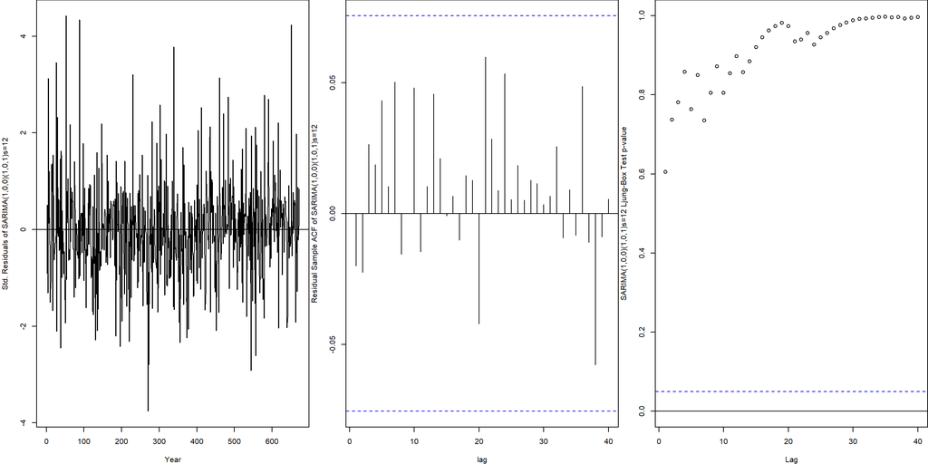

There is no apparent heteroscedasticity in the residual plot, and there are no significant residual lags, so the AR/MA terms were likely captured using model 4. The Ljung-Box test p-values are insignificant and increasing, indicating that the model is likely adequate.

## Predicted vs. actual, 10/1958-09/1961 with PIs

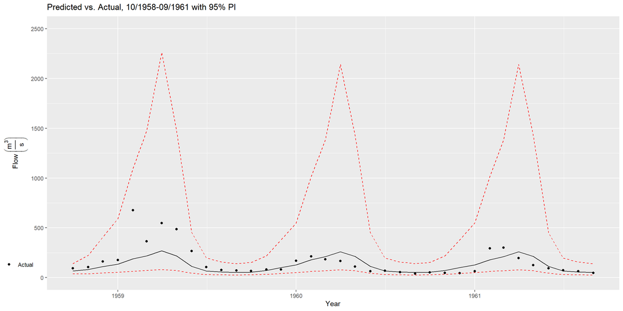

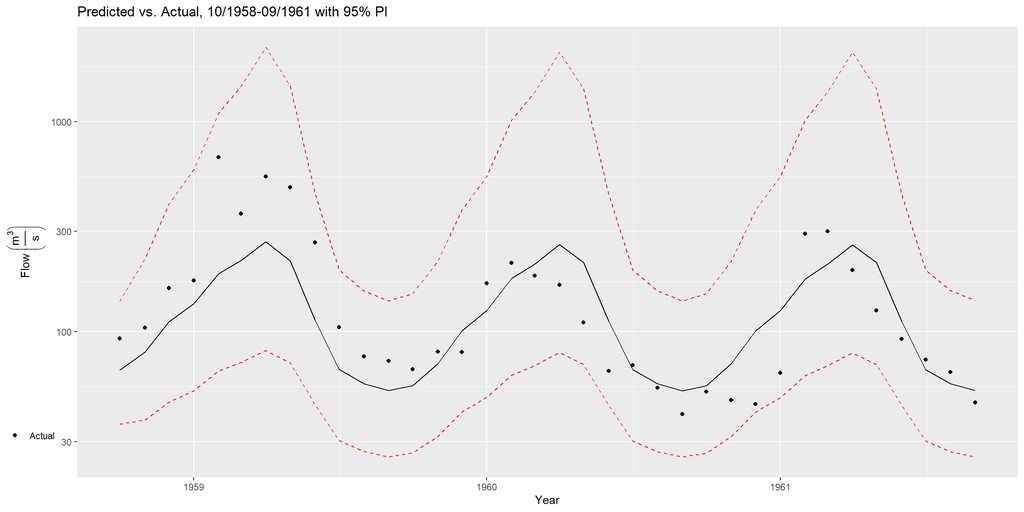

```
##
## Call:
## arima(x = ., order = c(1, 0, 0), seasonal = list(order = c(1, 0, 1), period = 12),
##     include.mean = T)
##
## Coefficients:
##          ar1    sar1     sma1  intercept
##       0.6807  0.9989  -0.9587     2.2496
## s.e.  0.0277  0.0015   0.0257     0.0578
##
## sigma^2 estimated as 0.005446:  log likelihood = 826.8,  aic = -1645.6
```

## Final Model if SARMA

$(1-\phi B)(1-\Phi B^{12})(\frac{X_{t}^{\lambda}-1}{\lambda}-\mu)=(1+\Theta B^{12})Z_{t}, Z_{t}\sim N(0,\sigma^{2})$

$\sigma^{2}=5.446\times 10^{-3}, \mu=2.2496$

$\phi=0.6807, \Phi=0.9989, \Theta=-0.9587$

## Future Predictions for SARMA

[figure not shown]

[figure not shown]

## Limitations of SARMA

There are possible ARCH-GARCH effects, so it is helpful to investigate ACF, PACF, of squared residuals and difference of squared residuals lag 12.

## ACF, PACF of squared residuals

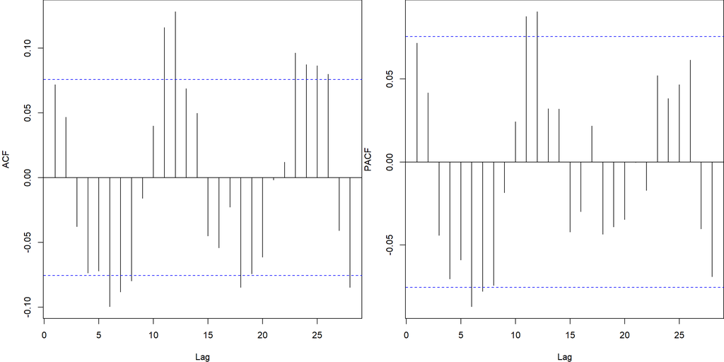

## ACF of differenced squared residuals lag 12

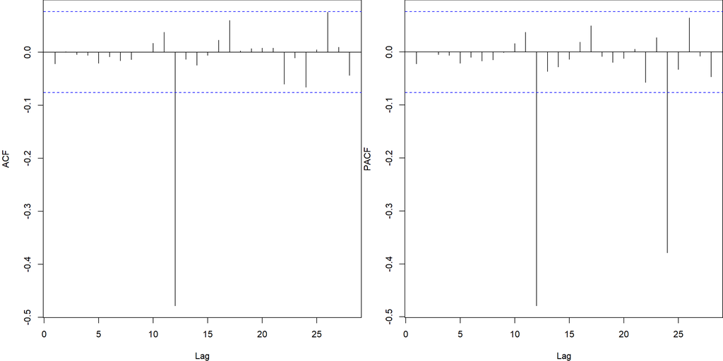

## Analysis of ARCH plots

There is a cyclical ACF and PACF but it is barely significant, but annual differencing reveals a strong negative autocorrelation for $l=12$ that cuts off and a negative partial autocorrelation for $l=12k$ that tapers. The squared residuals have an ACF similar to $SIMA(0,0)\times(1,1)_{s=12}$ which may indicate GARCH effects.

## Additive and multiplicative decomposition

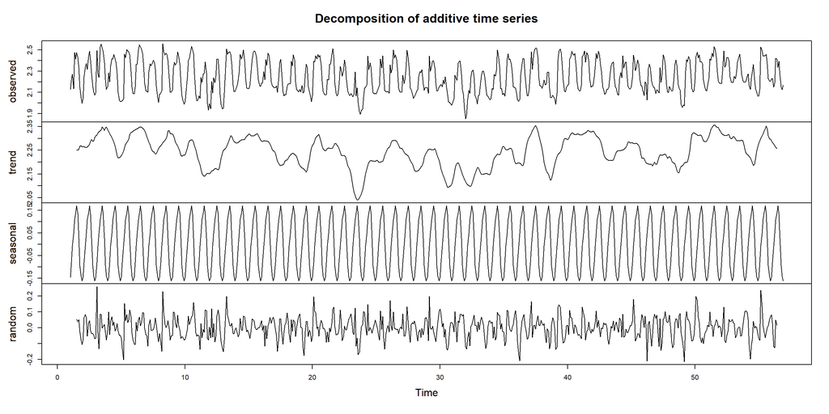

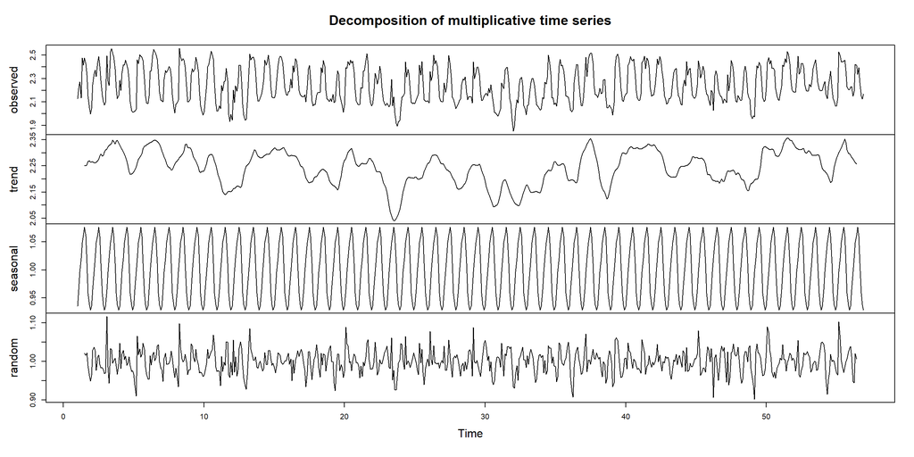

Classical decomposition shows that the trend term does not fan out or tend to trend in the positive or negative direction, and the random part does not appear to have a bias towards positive or negative residuals, though there may be volatility clustering.

## LOWESS decomposition

For LOWESS decomposition, because the Box-Cox fit for lambda was based off an autoregressive assumption, the un-transformed and log-transformed data should be fitted to models and compared.

```
## linearRMSE    logRMSE
##          4         24
```

```
##   ets.linearMAPE     ets.bxcxMAPE arima.linearMAPE    arima.logMAPE
##                3                1               10                2
##   arima.bxcxMAPE naive.linearMAPE    naive.logMAPE  rwdrift.logMAPE
##                4                5                2                1
```

## Plotting MAPE over time

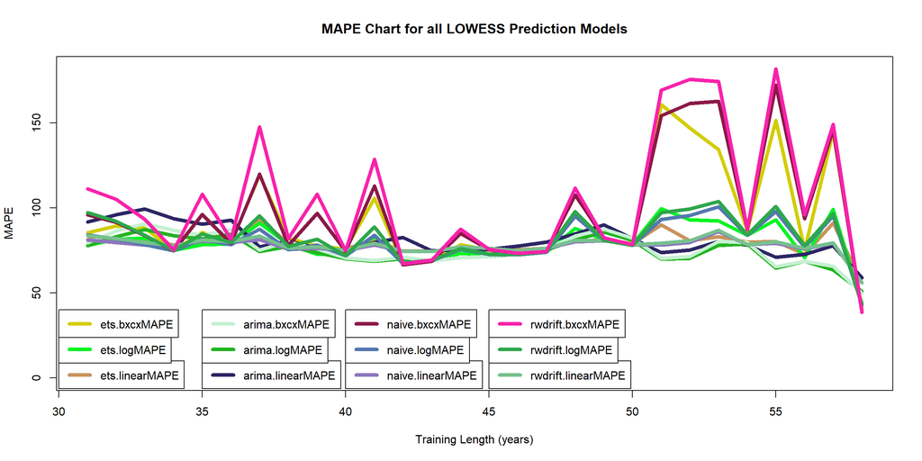

## Plotting forecasting for 36 months ahead

```
##   SARIMA MAPE ETS MAPE ARIMA MAPE Naive MAPE RWD MAPE
## 1    69.45628 70.73833   68.76745   76.91412 77.74366
```

```
## integer(0)
```

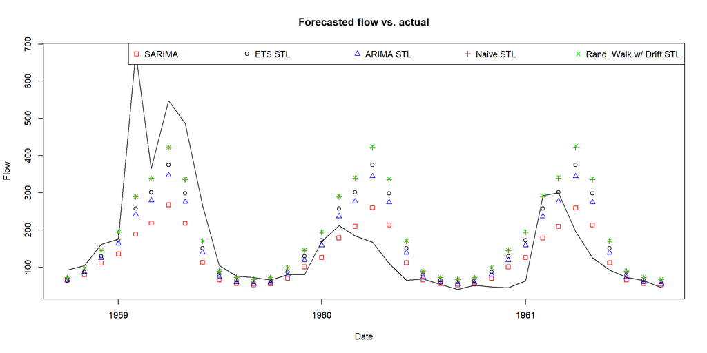

For a 36-month time scale, the ARIMA+log STL method of forecasting performed better than the original SARMA model from the first part. Further comparison across different time scales should be conducted to clear the ambiguity of model strength, but this should occur at the end.

## ETS

Because the data expresses strong seasonality and lacks a secular trend, the ideal model to use is the triple exponential smoothing method. For Box-Cox and logarithmic transformations, the prediction interval increases in width so greatly that cataclysmic droughts and floods fall within the 95% prediction interval.

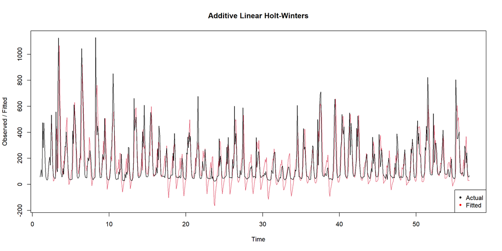

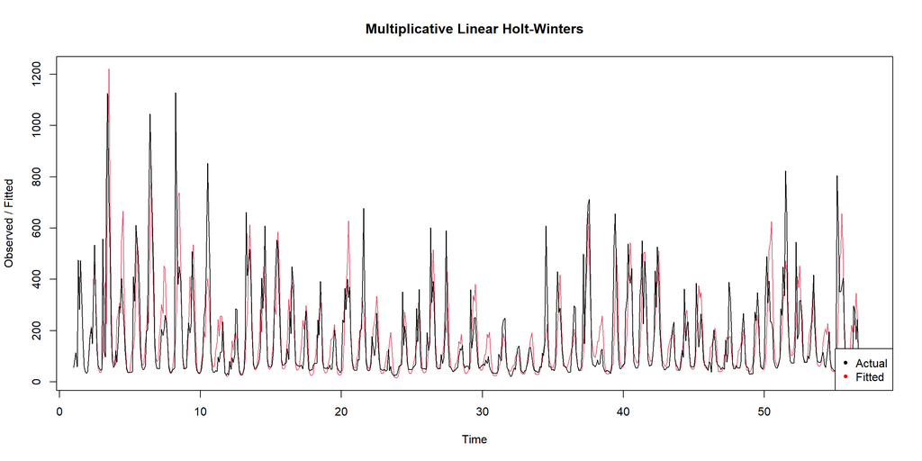

The additive linear model results in data points which are negative, so it can be ignored as the data should always be nonnegative.

```
## lin.mul.RMSE
##           28
```

```
## < table of extent 0 >
```

```
##   lin.mul.MAPE log.add.MAPE
## 1     68.35443     75.67659
```

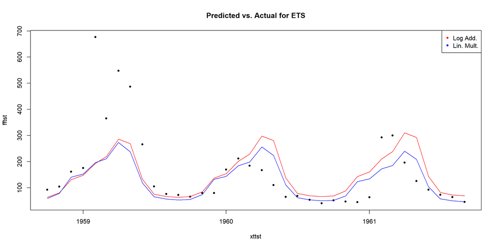

## Final Comparison

```
##    sc1.cm4MAPE dck.arima.logMAPE
## 1     84.69805          77.86466
## 2     90.02307          83.01401
## 3     94.50622          87.24115
## 4     90.93250          83.76490
## 5     88.62440          81.76725
## 6     89.95994          84.61783
## 7     78.02234          74.30514
## 8     83.41159          77.39139
## 9     78.50312          73.84280
## 10    73.46138          70.15435
## 11    68.06453          68.71800
## 12    66.90419          70.13064
## 13    69.62399          69.14953
## 14    71.42231          70.81762
## 15    72.93750          71.36184
## 16    77.37083          73.06482
## 17    78.72947          75.24696
## 18    85.02636          81.17384
## 19    88.27044          85.72201
## 20    85.17240          80.83737
## 21    72.09211          69.90177
## 22    71.36616          70.41919
## 23    77.74756          78.03116
## 24    85.11425          78.75428
## 25    63.96372          64.60988
## 26    69.45628          68.76745
## 27    40.71886          63.48764
## 28    42.69961          50.96124
```

Across the set of testing lengths, the original Box-Cox transformed SARMA model is outperformed by the log-transformed LOWESS model in terms of MAPE, but the STL model is significantly outperformed in short-term prediction. For long-term prediction, it may be wise to use STL, but for short-term prediction, SARMA may be beneficial, as even the STL suggests that prediction using an ARIMA model is the best means of prediction.

## Conclusion

The final model is thus:

$(1-\phi B)(1-\Phi B^{12})(\frac{X_{t}^{\lambda}-1}{\lambda}-\mu)=(1+\Theta B^{12})Z_{t}, Z_{t}\sim N(0,\sigma^{2})$

$\sigma^{2}=5.446\times 10^{-3}, \mu=2.2496$

$\phi=0.6807, \Phi=0.9989, \Theta=-0.9587$

As mentioned earlier, the primary issue with the SARMA model is its GARCH effects in the residuals. Fitting a GARCH model is outside the scope of this report and may induce overfitting.